```python
%load_ext skip_kernel_extension
```

# Einführung in die Physik SS 2020

### Übung 2: Kräfte

#### Arbeiten mit rechtwinkligen Dreiecken

[figure not shown]

1. Zwei **rechtwinkligen Dreiecke** sind genau dann **ähnlich**, wenn sie in **einem Winkel übereinstimmen** (siehe Bild oben), und es gelten: $$\frac{a}{x} = \frac{b}{y} = \frac{c}{z}.$$
2. Der Satz des Pythagoras $$c^2 = a^2 + b^2.$$
3. Trigonometrie im rechtwinkligen Dreieck:

$$\sin\alpha = \frac{a}{c}, \, \cos\alpha=\frac{b}{c}, \, \tan\alpha=\frac{a}{b}. \, \text{ Aus 1. folgt bspw: } \, \sin\alpha = \frac{a}{c} = \frac{x}{z}.$$

### Kraft

Die **Dynamik** fragt nach den **Ursachen einer Änderung des Bewegungszustandes**, dabei spielen dann die **Kräfte** eine Rolle.

Die Kraft hat eine Richtung, also ist sie **ein Vektor**. Wirkt eine Kraft auf einen Körper mit der Masse $m$, so wird dieser in Richtung der Kraft beschleunigt. Die Beschleunigung des Körpers $a$ ist dabei der angreifenden Kraft proportional:

$$\vec{F} = m\cdot \vec{a}$$

- Die Einheit ergibt sich zu [$F$] = 1 kg m s⁻² = N (Newton).
- Je größer die Masse, desto mehr Kraft braucht man, um die gleiche Beschleunigung zu erreichen, sie ist die träge Masse.
- $\vec{F}$ ist die Gesamtkraft, d.h. die Summe aller auf den Körper wirkenden Kräfte.

*Beispiel*: Beim freien Fall erfährt ein Körper eine **Beschleunigung** mit $g$. Aber auch wenn keine Fallbewegung möglich ist (z.B. wenn man auf dem Boden steht), wirkt die Erdbeschleunigung und verursacht eine **Gewichtskraft** gemäß:

$$\vec{F}_G = m\cdot \vec{g}$$

#### Kräftediagramme

Greifen an einem **Körper verschiedene Kräfte** an, so kann man mittels des **Superpositionsprinzips** die **resultierende Kraft** berechnen. Es ergibt sich ein so genanntes **Kräfteparallelogramm**:

[figure not shown]

$$\vec{F}_{ges} = \vec{F}_{1} + \vec{F}_{2}$$

### Aufgabe 1

Eine Straßenlaterne der Masse 25 kg wird mittig zwischen zwei Hauswänden von 10 m Abstand aufgehängt. Wie stark muss das Seil am Ort der Laterne mindestens durchhängen, damit die Belastung des Seils 10 kN nicht übersteigt?

*Hinweis*: $\frac{d}{\sqrt{(l/2)^2+d^2}} ≈ \frac{d}{l/2}$

[figure not shown]

Um die Übung besser zu verstehen, können Sie den folgenden Code ausführen und mit dem Plot spielen.

```python
from ipywidgets import interact, widgets
from exmodul import vector_plot1, b, dr
interact(vector_plot1, b = b, dr = dr)
```

```
<function exmodul.vector_plot1(b, dr)>
```

**a)** Leiten Sie auf dem Papier eine Formel für $d$ her.

#### Offizielle Lösung

Betrachte die beiden ähnlichen Dreiecke:

$$\frac{\frac{m\cdot g}{2}}{F_S} = \frac{d}{\sqrt{(l/2)^2+d^2}} ≈ \frac{d}{l/2}$$$$ \Rightarrow d = \frac{l\cdot m \cdot g}{4\cdot F_s} = \frac{10 \text{ m }\cdot 25 \text{ kg}\cdot 9,81 \frac{\text{ m}}{\text{s}^2}}{4\cdot 10 \text{ kN}} =0,061 \text{ m}$$

#### Alternativ

$$h = \sqrt{(l/2)^2+d^2} \Rightarrow \sin\alpha = \frac{d}{h}$$$$ \sin\alpha = \frac{F_G/2}{F_{S_1}}= \frac{d}{h} ≈ \frac{d}{l/2}$$$$ \Rightarrow d = \frac{l\cdot m \cdot g}{4\cdot F_s} = \frac{10 \text{ m }\cdot 25 \text{ kg}\cdot 9,81 \frac{\text{ m}}{\text{s}^2}}{4\cdot 10 \text{ kN}} =0,061 \text{ m}$$

#### Alternativ (ohne Hinweis)

$$ \sin\alpha = \frac{F_G/2}{F_{S_1}}= \frac{d}{h}$$$$\Rightarrow d = \frac{\frac{F_G\cdot l}{4F_S}}{\sqrt{1- (\frac{F_G}{2F_{S_1}})^2}} $$

**b)** Berechnen Sie das numerische Ergebnis in der folgenden Code-Zelle.

**Code Tips:**

- Die trigonometrischen Funktionen $\sin, \cos$ und $\tan$ sind z. B. in `math` implementiert. D. h. mit `math.sin(x), math.cos(x), math.tan(x)` können Sie sie für ein in **Radiant** gegebenes `x` aufrufen (`math.radians(x)`).
- Die Erdbeschleunigung $g$ können Sie über das Modul `scipy.constants` mit `const.g` einbinden. Die funktioniert übrigens auch für viele andere physikalische Konstanten.

```python
import math
import scipy.constants as const

m = 25       # Masse der Straßenlanterne in kg
L = 10       # Abstand zwischen zwei Hauswänden in m
B = 10e3     # Maximale Belastung de Seils in N
g = const.g  # Erdbeschleinigung

d = 5*g*m/math.sqrt((2*B)**2-(m*g)**2)

print("Das Seil muss mindestens" , round(d,3) ,"m durchhängen.")
```

```
Das Seil muss mindestens 0.061 m durchhängen.
```

Die **Normalkraft** wirkt immer **senkrecht** zur **Auflagefläche** auf den Körper. Bei horizontaler Auflagefläche entspricht die Normalkraft im Betrag der Gewichtskraft des Körpers. Reaktio der Ebene.

#### Schiefe Ebene

Das Superpositionsprinzip benutzt man auch umgekehrt, wenn man Kräfte in Komponenten zerlegen will. Auf den Körper wirkt die Gewichtskraft $\vec{F}_G$. Man zerlegt sie in den Hangabtrieb $\vec{F}_{H,G}$ parallel zur Ebene und die Normalkraft $\vec{F}_{N,G}$ senkrecht dazu. Die vektorielle Summe von $\vec{F}_{H,G}$ und $\vec{F}_{N,G}$ ergibt wieder $\vec{F}_G$. Der Nutzen der in der Abbildung gezeigten Zerlegung liegt darin, dass $\vec{F}_{N,G}$ senkrecht zur Bewegungsrichtung zeigt und damit keinen Einfluss auf die Bewegung auf der Ebene hat. Sie wird alleine von $\vec{F}_{H,G}$ bestimmt, welches exakt in Bewegungsrichtung zeigt.

[figure not shown]

### Aufgabe 2

Die Turmbergbahn ist die älteste noch in Betrieb befindliche Standseilbahn Deutschlands. Sie fährt von Karlsruhe-Durlach auf den Turmberg. Auf einer Gleislänge von 315 m überwindet sie einen einen Höhenunterschied von 100 m, wobei die Steigung an der steilsten Stelle 36,2 % beträgt. Das Zugseil besitzt eine Bruchfestigkeit von 422 kN. Wie schwer dürfte dann ein Wagen der Bahn vollbesetzt maximal sein? Bitte geben Sie Ihr Ergebnis in Tonnen aus.

Um die Übung besser zu verstehen, können Sie den folgenden Code ausführen und mit dem Plot spielen. Der zeigt an, wie sich das Gewicht bei konstanter Bruchfestigkeit des Zugseils in Abhangigkeit von die Steigung ändert.

```python
from exmodul import vector_plot2, n
interact(vector_plot2, n = n)
```

```
<function exmodul.vector_plot2(n)>
```

**a)** Leiten Sie auf dem Papier eine Formel für $m$ her.

#### Offizielle Lösung

Betrachte die beiden ähnlichen rechtwinkligen Dreiecke. Sie sind ähnlich, da sie paarweise aufeinander senkrecht stehen.

$$\tan\alpha = 0,362; \, \, \frac{F_H}{F_G} = \sin\alpha$$$$ \Rightarrow F_G = \frac{F_H}{\sin\alpha}= \frac{4,22\cdot10^5 \text{ N}}{\sin(\arctan(0,362))} = 1,24\cdot 10^6 \text{ N}$$

**b)** Berechnen Sie das numerische Ergebnis in der folgenden Code-Zelle.

```python
s = 0.362     # Steigung in -
F_H = 422e3   # Hangabtrieb in N
g = const.g   # Erdbeschleinigung in m/s²

F_G = F_H/math.sin(math.atan(s))

m = F_G/g

print("Ein Wagen dürfte" , round(m/1000) ,"Tonnen schwer sein.")
```

[output not shown]

#### Reibung

Die Bewegung eines Körpers auf einer Unterlage wird durch eine **Reibungskraft** $F_R$ gehemmt, welche der **bewegenden Kraft** entgegen gerichtet und von der Oberflächenbeschaffenheit abhängig ist. $F_R$ ist **unabhängig** von der **Auflagefläche** und der **Geschwindigkeit**.

Im folgenden betrachten wir die Festkörperreibung, wobei wir zwischen Haft- und Gleitreibung unterscheiden:

[figure not shown]

(1, 2) Die **Haftreibung** ist mit der Normalkraft über den Reibungskoeffizienten $\mu_H$ verknüpft: $$F_{R} \leq \mu_H F_N$$

(3) Der Körper beginnt zu rutschen (**maximale Haftreibung**), wenn gilt $F_{R,max} = \mu_H F_N$.

(4) Wenn der Körper gleitet, ist die Reibungskraft geringer (**Gleitreibung**), es gilt: $$F_{R} = \mu_G F_N$$ mit $ \mu_G \leq \mu_H$.

#### Schiefe Ebene mit Reibung

Die Gewichtskraft $\vec{F_G}$ wurde in die Normalkraft $\vec{F}_{N,G}$ senkrecht zur Ebene und den Hangabtrieb $\vec{F}_{H,G}$ parallel zur Ebene zerlegt. Der Körper drückt mit der Normalkraft auf die Ebene. Diese wird durch die Reactio der Ebene, die in umgekehrter Richtung zeigt, ausgeglichen. Die Haftreibungskraft $\vec{F}_{R,\text{Haft}}$ muss den Hangabtrieb kompensieren, sodass sich $\vec{F_G}$, $\vec{F_N}$ und $\vec{F}_{R,\text{Haft}}$ zu null addieren und der Körper in Ruhe bleibt.

[figure not shown]

Die Rutschbedingung ist: $\mu_H=\tan\alpha$.

### Aufgabe 3

Sie begeben sich mit ihren Kommilitonen auf eine Skifahrt an einem bergigem Gelände. Dort finden sie Stellen verschiedener Neigung. Der Haftreibungskoeffizient sei je nach Beschaffenheit des Schnees ebenfalls unterschiedlich. Wir wollen nun schrittweise herausfinden, wann die Reibungkraft von der Hangabtriebskraft überboten wird, so dass man ohne Abstoßen von alleine anfängt, den Hang herunterzufahren. Das wir Skifahrer mit unterschiedlichem Massen $m$, Skipisten mit unterschiedlicher Neigung $\alpha$ und unterschiedlichen Schnee mit unterschiedlichen Haftreibungskoeffizienten $\mu_H$ haben, variieren wir diese Größen.

*Hinweis*: Als Hilfsmittel haben wir die Funktion `reibung_plots` schon erstellt, die die Ergebnisse Ihrer Funktionen darstellt.

**a)** Erstellen Sie für die Reibungskraft $F_R$ und die Hangabtriebskraft $F_H$ je eine Funktion in Python, die von der Masse, der Neigung und dem Haftreibungskoeffizienten abhängen. Testen Sie Ihre Funktion mit $\alpha = 10°$ und sehr stumpfem Schnee mit einem Haftreibungskoeffizienten von $\mu_H=0,37$ sowie einem/einer Skifaher*in mit $m=75$kg.

**Code Tipps:**

- Eine Funktion kann man in folgender Form deklarieren:

  ```
  def Funktionsname(Argumente):
          Funktionsanweisungen
          return Resultat
  ```

- Eine Funktion kann auch nichts zurückgeben, sondern bpsw. nur etwas printen.
- Eine Funktion kann auch mit Arrays arbeiten, dafür müssen Sie `np.vectorize()` anwenden.

**Vorsicht!**

In Python sind Einrückungen (*engl.* indentation) essentiell. Der Editor hier hilft Ihnen aber dabei diese einzuhalten. Die Einrückung erfolgt normalerweise nach der Eingabe vom Doppelpunkt (`:`).

```python
import numpy as np

def F_R(alpha, m, mu_H):
    F_R =                #schreibe hier deine Formel rein
    return F_R

def F_H(alpha, m, mu_H):
    F_H =                 #schreibe hier deine Formel rein
    return F_H
```

```python
import numpy as np

def F_R(alpha, m, mu_H):
    F_R = mu_H*m*g*math.cos(math.radians(alpha))
    return F_R

def F_H(alpha, m, mu_H):
    F_H = m*g*math.sin(math.radians(alpha))
    return F_H
```

**Code Tips:**

Numerische Folgen:

- Die `linspace`-Funktion von NumPy berechnet eine bestimmte Anzahl von Werten innerhalb der gegebenen Anfangs- und Endpunkte. Die Syntax ist: `np.linspace(Anfangswert, Endwert, Schritte)`.
- Wenn die Schritte nicht angegeben wird, gibt `np.linspace` standardmäßig 50 Werte an.

```python
from exmodul import reibung_plots
F_R = np.vectorize(F_R)# Funktion nimmt nun Felder an
F_H = np.vectorize(F_H)

m = np.linspace(0, 100) #wir schauen uns die Massen zwischen 0 und 100 kg an
a =       #setzte die Werte in F_R ein
b =       #setzte die Werte in F_H ein

reibung_plots(F_R=a, F_H=b, m=m)
reibung_plots(F_R=F_R(10, m, 0.3), F_H=F_H(10, m, 0.3), m=m)
```

[output not shown]

```python
from exmodul import reibung_plots
F_R = np.vectorize(F_R)# Funktion nimmt nun Felder an
F_H = np.vectorize(F_H)

m = np.linspace(0, 100) #wir schauen uns die Massen zwischen 0 und 100 kg an
a = F_R(10, m, 0.3)
b = F_H(10, m, 0.3)

reibung_plots(F_R=a, F_H=b, m=m)
reibung_plots(F_R=F_R(10, m, 0.3), F_H=F_H(10, m, 0.3), m=m)
```

[output not shown]

**c)** Nun wollen wir untersuchen, wie die Kräfte vom Haftreibungskoeffizienten $\mu_H$ des Schnees abhängen. Gehen Sie von einem Skifahrer der Massse $75~\mathrm{kg}$ wieder auf der blauen Anfängerpiste mit $\alpha = 10°$ aus. Tragen Sie nun die Kräfte in Abhängigkeit vom Haftreibungskoeffizienten ($0-0,5$) auf. Wie rutschig muss der Schnee sein, damit der Skifahrer ohne Abstoßen anfängt, sich zu bewegen?

[figure not shown]

```python
mu_H = np.linspace(0, 0.5)

reibung_plots(F_R=   , F_H=  , mu_H=mu_H)
```

```python
mu_H = np.linspace(0, 0.5)

reibung_plots(F_R=F_R(10, 75, mu_H), F_H=F_H(10, 75, mu_H), mu_H=mu_H)
```

**d)** Nun wollen wir den Verlauf der Kräfte unter variierender Masse untersuchen. Dazu variieren wir die Neigung und schauen uns an, wie sich der Schnittpunkt für verschiedene Massen verhält. Was kannst du darüber über die Bedeutung der Masse für die Fragestellung, wann die Kräftegleichheit gilt, folgern?

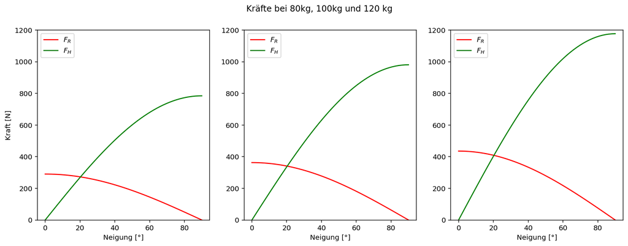

```python
mu_H = 0.37
alpha = np.linspace(0, 90)
reibung_plots(F_R=F_R, F_H=F_H, mu_H=mu_H, alpha=alpha)
```

Masse ist irrelevant.

**e)** Begründe deine Folgerung aus d) mathematisch. Welche Bedingung ist gegeben, für den Fall, dass gerade die Neigung reicht, damit ihr ohne Abstoßen den Hang herunterfährt?

Für den Grenzfall gilt, dass die Hangabtriebskraft $F_H$ gleich der Haftreibungskraft $F_R$ ist:

$$F_H = F_R$$$$m\cdot g \cdot\sin\alpha = \mu_H \cdot m\cdot g \cdot\cos\alpha $$

$$\tan\alpha = \mu_H$$

D.h. für $\tan\alpha > \mu_H$ beginnt man zu fahren, unabhängig davon, wie sich die Masse ändert.

**f)** Schreiben Sie eine Funktion, die für gegebenen Neigungswinkel $\alpha$ bestimmt, ob der Skifahrer ohne Abstoßen herunterfahren kann oder nicht. Verwenden Sie für Masse und Haftreibungskoeffizienten die Werte aus b) und testen Sie die Funktion für mehrere Werte des Neigungswinkels.

**Code Tips:**

`if-else` Verzweigungen dienen dazu bei unterschiedlichen Fällen auch unterschiedliche Anweisungen auszuführen. Die Synatx ist:

```
if Bedingung:
    Anweisung
else:
    Anweisung
```

- Bedingung mit rationalen Operatoren:
  - `==` Gleichheit
  - `!=` Ungleichheit
  - `<,>` strenge Vergleichoperatoren
  - `<=,>=` Vergleichoperatoren

**Vorsicht!**

Verzweigungen sind Codeteile, die unter bestimmten Bedingungen ausgeführt werden. Liegt die Bedingung **nicht vor**, wird dieser Code **nicht ausgeführt**.

```python
def losfahren_ja_nein(alpha):
    if                               #füge hier die Bedingung hinzu
        print('Winkel:', round(alpha,2), 'grad. Wir fahren ohne Abstoß, Hurra!')
    else:
        print('Winkel:', round(alpha,2),'grad. Die Reibung ist zu groß, erst nach Abstoß beginnt der Spaß.')

losfahren_ja_nein(10)
```

```python
def losfahren_ja_nein(alpha):
    if #F_R(alpha, 75, 0.37) < F_H(alpha, 75, 0.37):
        print('Winkel:', round(alpha,2), 'grad. Wir fahren ohne Abstoß, Hurra!')
    else:
        print('Winkel:', round(alpha,2),'grad. Die Reibung ist zu groß, erst nach Abstoß beginnt der Spaß.')

losfahren_ja_nein(10)
```

#### Newtonschen Axiome

> **1. Newtonsches Axiom:** Trägheitsgesetz. Ein Körper verharrt im Zustand der Ruhe oder der gleichförmigen Bewegung, sofern er nicht durch einwirkende Kräfte zur Änderung seines Zustands gezwungen wird.  
> Ruhe ist nur ein Sonderfall einer geradlinig gleichförmigen Bewegung mit Geschwindigkeit null, es herrscht **Gleichgewicht**.

> **2. Newtonsches Axiom:** Aktionsgesetz. Die Änderung der Bewegung ist der Einwirkung der bewegenden Kraft proportional und geschieht nach der Richtung derjenigen geraden Linie, nach welcher jene Kraft wirkt. $$\vec{F} = m\cdot \vec{a}.$$
- $\vec{F}$ ist **die Gesamtkraft**, d.h. die Summe aller auf den Körper wirkenden Kräfte.
- Das 1. Axiom ist ein **Spezialfall** des 2. Axioms: $\vec{F} = \vec{0} \Leftrightarrow \vec{a} = \vec{0} \Rightarrow \vec{v} = \text{const.}$

> **3. Newtonsches Axiom:** Wechselwirkungsgesetz. Wirkt ein Körper auf einen zweiten mit einer bestimmten Kraft, so wirkt der zweite auf den ersten zurück und mit der gleichen, aber entgegen gerichteten Kraft. $$\vec{F}_{\text{actio}} = -\vec{F}_{\text{reactio}}.$$ In der Natur treten Kräfte also immer **paarweise** auf!
> Wichtig: Hierbei handelt es sich um Kräfte, die auf **zwei verschiedene Körper** wirken!

### Aufgabe 4

Betrachten Sie zwei Massen, die mit einem einen Seil über eine Umlenkrolle miteinander verbunden sind und reibungsfrei auf zwei senkrecht aufeinander stehenden Ebenen gleiten können (siehe Skizze). Wie groß muss bei gegebenem Winkel $\theta$ das Verhältnis der Massen sein, damit diese in Ruhe bleiben? Wie groß ist bei gleich großen Massen die Beschleunigung $a$ in Abhängigkeit von $\theta$?

[figure not shown]

**a)** Was muss gelten, damit das System in Ruhe bleibt? Verwenden Sie diese Bedingung, um die Beziehung zwischen dem Verhältnis der Massen und dem Winkel zu finden.

**Trägheitsgesetz** $\vec{F} = \vec{0}$. Für die Hangabtriebskraft gilt bei Hang mit Winkel $\alpha$ zur Horizontalen:

$$F_H = F_G \cdot \sin\alpha = m\cdot g\cdot \sin\alpha$$

Auf der linken Seite ist $\alpha = 90° − \theta$, auf der rechten Seite $\alpha = \theta$

**b)** Falls das System nicht mehr in Ruhe bleibt, was muss gelten? Verwenden Sie diese Bedingung, um die Beziehung zwischen der Beschleunigung und dem Winkel zu finden.

**Aktionsgesetz** $\vec{F} = m\cdot \vec{a}$ Dann gilt für die Beschleunigung:

$$a = \frac{F_1 - F_2}{m_1 + m_2}= g\frac{m_1 \cdot\cos\theta-m_2 \cdot\sin\theta}{m_1 + m_2}$$

Für gleiche Massen erhält man als Beschleunigung:

$$m_1 = m_2 \Leftrightarrow a = \frac{g}{2}(\cos\theta- \sin\theta)$$